Friday, 6<sup>th</sup> of September (2019)

## Introduction

### NanoString™ nCounter® & R packages

## NanoString™ nCounter®

[video not shown]

## NanoString™ nCounter®

The nCounter® platform provides a simple and cost effective solution for multiplex analysis of *up to 800 RNA, DNA, or protein targets* from your precious samples.

- Save Time
  - Expertly curated pre-formatted panels for human, mouse and non-human primate
  - ~15-minutes total hands-on time with *no amplification*, *cDNA conversion* or *library prep* required
- Save Sample
  - *Combine RNA, DNA, and protein panels* for a comprehensive 3D Biology™ view of each sample
  - *Optimized performance on difficult sample types* including FFPE, tissue, lysates and biofluid samples

## NanoString™ nCounter®

- Save Resources
  - Advanced analysis tools included with system reduce the need for Bioinformatics support

[figure not shown]

## NanoString™ nCounter® nSolver™

[figure not shown]

## NanoString™ nCounter® nSolver™

nSolver 4.0 ressources:

- [Quick Start guide](https://www.nanostring.com/download_file/view/1170/8241)
- [User Manual](https://www.nanostring.com/download_file/view/1168/8241)

[figure not shown]

[figure not shown]

[figure not shown]

[figure not shown]

## nSolver™ alternatives?

- NanoStringNorm
  - On CRAN
  - Since 2011-09-16
  - Last 2017-11-10
- nanostringr
  - On CRAN
  - Since 2019-03-15
  - Last 2019-04-24
- [NanoStringDiff](https://www.bioconductor.org/packages/NanoStringDiff/)
  - On Bioconductor
  - Since 2016-04-23
  - Last 2018-01-24
- [NanoStringQCPro](https://www.bioconductor.org/packages/NanoStringQCPro/)
  - On Bioconductor
  - Since 2015-08-13
  - Last 2018-04-10

## Our alternative: *NACHO*

- NACHO on CRAN (Since 2019-04-28; Next 2019-10)

[figure not shown]

[figure not shown]

[figure not shown]

### (**NA**nostring quality **C**ontrol das**H**b**O**ard)

## Overview

*NACHO* (**NA**nostring quality **C**ontrol das**H**b**O**ard) is developed for NanoString nCounter data.

*NACHO* is able to **load**, **visualise** and **normalise** the exported NanoString nCounter data and facilitates the user in performing a quality control.

*NACHO* does this by visualising in an **interactive** web application:

- **quality control metrics**
- **expression of control genes**
- **principal components**
- **sample specific size factors**

## The functions

RCC files are summarised and visualised using two functions:

- The `summarise()` function is used to preprocess the data.
- The `visualise()` function initiates a [Shiny-based dashboard](https://shiny.rstudio.com/) that visualises all relevant QC plots.

*NACHO* also includes a function `normalise()`, which (re)calculates sample specific size factors and normalises the data.

- The `normalise()` function creates a list in which your settings, the raw counts and normalised counts are stored.

## Let’s play a bit with

[figure not shown]

## Get some RCC files from GEO

```r
library(GEOquery)
gse <- getGEO("GSE70970")
targets <- pData(phenoData(gse[[1]]))
getGEOSuppFiles(GEO = "GSE70970", baseDir = ".")
untar(
  tarfile = "./GSE70970/GSE70970_RAW.tar",
  exdir = "./GSE70970/Data"
)
targets$IDFILE <- list.files("./GSE70970/Data")
```

## Load RCC files with `summarise()`

The `housekeeping_genes` and `normalisation_method` arguments respectively indicate which housekeeping genes and normalisation method should be used.

```r
library(NACHO)
GSE70970_sum <- summarise(
  data_directory = "./GSE70970/Data",
  ssheet_csv = targets,
  id_colname = "IDFILE",
  housekeeping_genes = NULL,
  housekeeping_predict = TRUE,
  normalisation_method = "GEO",
  n_comp = 5
)
```

## Load RCC files with `summarise()`

```r
GSE70970_sum
```

```
#> List of 13
#>  $ access              : chr "IDFILE"
#>  $ housekeeping_genes  : chr [1:5] "hsa-miR-103" "hsa-let-7e" "hsa-miR-1260" "hsa-miR-500+hsa-miR-501-5p" ...
#>  $ housekeeping_predict: logi TRUE
#>  $ housekeeping_norm   : logi TRUE
#>  $ normalisation_method: chr "GEO"
#>  $ remove_outliers     : logi FALSE
#>  $ n_comp              : num 5
#>  $ data_directory      : chr "/home/travis/build/mcanouil/NACHO_slides/GSE70970/Data"
#>  $ pc_sum              :'data.frame':    5 obs. of  4 variables:
#>  $ nacho               :'data.frame':    198170 obs. of  112 variables:
#>  $ outliers_thresholds :List of 6
#>  $ raw_counts          :'data.frame':    792 obs. of  265 variables:
#>  $ normalised_counts   :'data.frame':    792 obs. of  265 variables:
#>  - attr(*, "RCC_type")= chr "n1"
#>  - attr(*, "class")= chr "nacho"
```

## (re)Normalise with `normalise()`

*NACHO* allows the discovery of housekeeping genes within your own dataset.

*NACHO* finds the five best suitable housekeeping genes, however, it is possible that one of these five genes might not be suitable.

The discovered housekeeping genes are saved in a global variable named **predicted_housekeeping**.

```r
GSE70970_sum[["housekeeping_genes"]]
```

```
#> [1] "hsa-miR-103"                "hsa-let-7e"
#> [3] "hsa-miR-1260"               "hsa-miR-500+hsa-miR-501-5p"
#> [5] "hsa-miR-1274b"
```

## (re)Normalise with `normalise()`

Let’s say `"GEO"` is not the best normalisation for our dataset and we want to use `"GLM"` instead.

```r
GSE70970_norm <- normalise(
  nacho_object = GSE70970_sum,
  normalisation_method = "GLM",
  remove_outliers = TRUE
)
```

## (re)Normalise with `normalise()`

```r
GSE70970_norm
```

```
#> List of 13
#>  $ access              : chr "IDFILE"
#>  $ housekeeping_genes  : chr [1:5] "hsa-let-7e" "hsa-miR-1260" "hsa-miR-1274b" "hsa-miR-103" ...
#>  $ housekeeping_predict: logi TRUE
#>  $ housekeeping_norm   : logi TRUE
#>  $ normalisation_method: chr "GLM"
#>  $ remove_outliers     : logi TRUE
#>  $ n_comp              : num 5
#>  $ data_directory      : chr "/home/travis/build/mcanouil/NACHO_slides/GSE70970/Data"
#>  $ pc_sum              :'data.frame':    5 obs. of  4 variables:
#>  $ nacho               :'data.frame':    115271 obs. of  112 variables:
#>  $ raw_counts          :'data.frame':    792 obs. of  155 variables:
#>  $ normalised_counts   :'data.frame':    792 obs. of  155 variables:
#>  $ outliers_thresholds :List of 6
#>  - attr(*, "RCC_type")= chr "n1"
#>  - attr(*, "class")= chr "nacho"
```

## It’s Shiny time (`visualise()`)

```
#> [NACHO] Custom "outliers_thresholds" can be loaded for later use with:
#>   outliers_thresholds <- readRDS("outliers_thresholds.rds")
```

[figure not shown]

```r
visualise(GSE70970_sum)
```

## What’s next ?

### v0.6.0 & v1.0.0

## v0.6.0 (Release: October 2019)

*NACHO* includes two (three) additional functions:

- The `render()` function renders a full quality-control report (HTML) based on the results of a call to `summarise()` or `normalise()` (using `print()` in a Rmarkdown chunk).
- The `autoplot()` function draws any quality-control metrics from `visualise()` and `render()`.

## The `autoplot()` function

The `autoplot()` function provides an easy way to plot any quality-control from the `visualise()` function.

- `"BD"` (Binding Density)
- `"FoV"` (Imaging)
- `"PC"` (Positive Control Linearity)
- `"LoD"` (Limit of Detection)
- `"Positive"` (Positive Controls)
- `"Negative"` (Negative Controls)
- `"Housekeeping"` (Housekeeping Genes)
- `"PN"` (Positive Controls vs. Negative Controls)
- `"ACBD"` (Average Counts vs. Binding Density)
- `"ACMC"` (Average Counts vs. Median Counts)
- `"PCA12"` (Principal Component 1 vs. 2)
- `"PCAi"` (Principal Component scree plot)
- `"PCA"` (Principal Components planes)
- `"PFNF"` (Positive Factor vs. Negative Factor)
- `"HF"` (Housekeeping Factor)
- `"NORM"` (Normalisation Factor)

## The `autoplot()` function

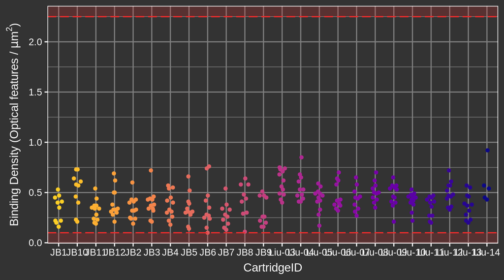

```r
autoplot(GSE70970_sum, x = "BD")
```

## The `autoplot()` function

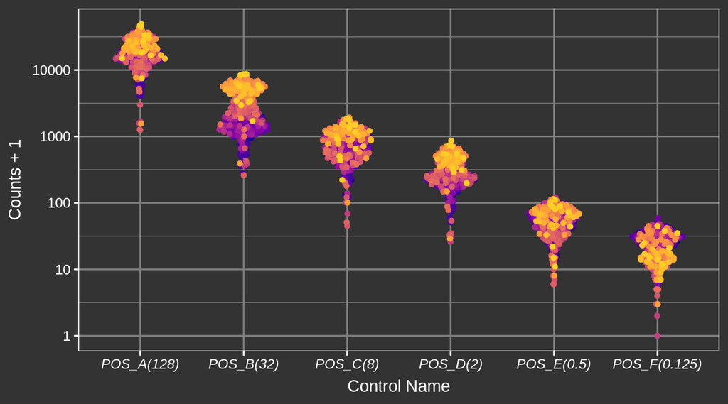

```r
autoplot(GSE70970_sum, x = "Positive")
```

## The `autoplot()` function

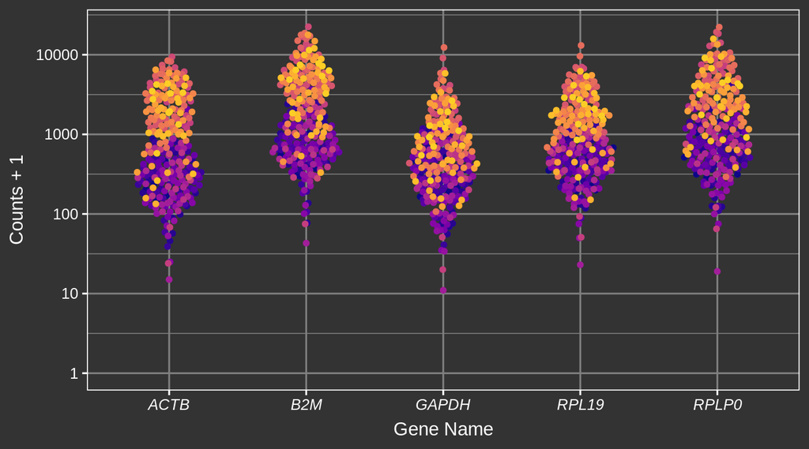

```r
autoplot(GSE70970_sum, x = "Housekeeping")
```

## The `autoplot()` function

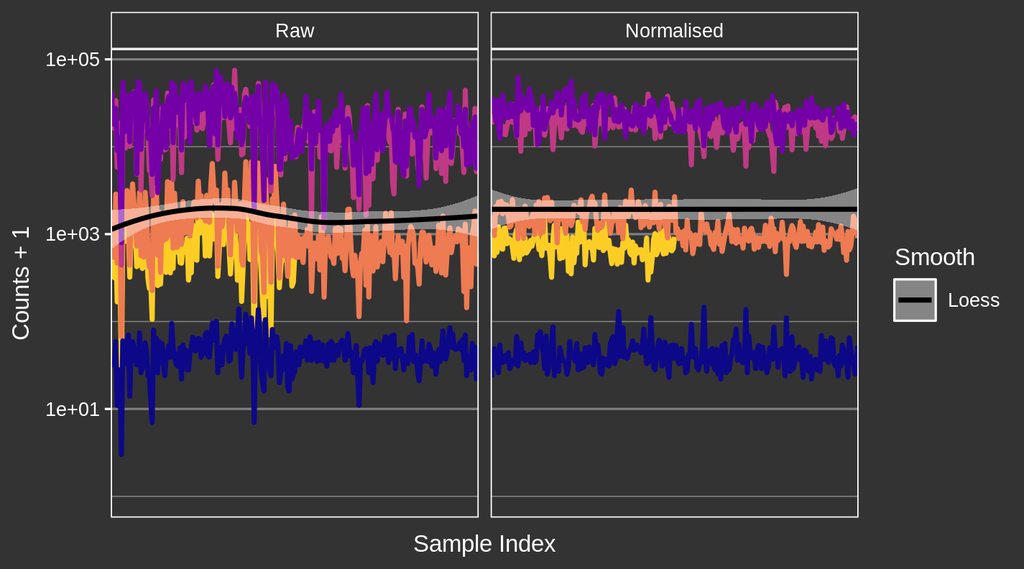

```r
autoplot(GSE70970_sum, x = "NORM")
```

## The `render()` function

The `render()` function renders (using `print(..., echo = TRUE)` a comprehensive HTML report which includes all quality-control metrics and description of those metrics.

```r
render(
  nacho_object = GSE70970_sum,
  colour = "CartridgeID",
  output_file = "NACHO_QC.html",
  output_dir = "./GSE70970/",
  size = 0.5,
  show_legend = TRUE,
  clean = TRUE
)
```

## The `print()` function

The underneath function `print()` can be used directly within any Rmakrdown chunk, setting the parameter `echo = TRUE`.

```r
print(
  x = GSE70970_sum,
  colour = "CartridgeID",
  size = 0.5,
  show_legend = TRUE,
  echo = TRUE,
  title_level = 3
)
```

## v1.0.0

- Code rewrite and optimisation
- Normalisation method template

[figure not shown]

### (**C**entralised and **A**utomated **R**ep**o**rting **T**ools )

## What is CARoT?

*CARoT* (Centralised and Automated Reporting Tools) is an under development set of Quality-Control reporting tools and some other functions.

Currently *CARoT* includes the following main functions:

- `estimate_ethnicity()` Compute the genomic component (ethnicity)
- `pca_report()` Compute a principal component analysis
- `qc_idats()` QC of methylation array
- `qc_plink()` QC of genotyping array
- `qc_impute()` QC of imputated genotyping array

[figure not shown]

+33 (0) 374 00 81 29

mickael.canouil@cnrs.fr

mickael.canouil.fr

mickael-canouil

mcanouil

[@mickaelcanouil](https://twitter.com/mickaelcanouil)

## References

Bruce, J. P., Hui, A. B. Y., Shi, W., Perez-Ordonez, B., Weinreb, I., Xu, W., … Liu, F.-F. (2015). Identification of a microRNA signature associated with risk of distant metastasis in nasopharyngeal carcinoma. *Oncotarget*, *6*(6), 4537–4550. https://doi.org/10.18632/oncotarget.3005